# DA HW5 박정명

2022-12-04

# Preparing data

```r
data = iris
# x=data[,-5]; y=data$Species
set.seed(1111)
n <- nrow(data)
iris_parts <- data %>%
  initial_split(prop = 2/3)
train <- iris_parts %>%
  training()
test <- iris_parts %>%
  testing()
```

# Question 1

## Question 1a) KNN

```r
train %>% glimpse ()
```

```
## Rows: 100
## Columns: 5
## $ Sepal.Length <dbl> 5.0, 5.0, 5.0, 5.0, 5.6, 6.5, 6.0, 4.4, 5.6, 7.2, 5.1, 4.…
## $ Sepal.Width  <dbl> 3.5, 3.3, 3.0, 3.2, 2.5, 3.2, 2.2, 3.0, 2.9, 3.0, 3.5, 3.…
## $ Petal.Length <dbl> 1.6, 1.4, 1.6, 1.2, 3.9, 5.1, 4.0, 1.3, 3.6, 5.8, 1.4, 1.…
## $ Petal.Width  <dbl> 0.6, 0.2, 0.2, 0.2, 1.1, 2.0, 1.0, 0.2, 1.3, 1.6, 0.3, 0.…
## $ Species      <fct> setosa, setosa, setosa, setosa, versicolor, virginica, ve…
```

```r
#Knn can't use categorical variable- select only the numerical variables
#All variables are numerical variables anyways


k_vals =seq(1,10,2)

accuracy_cmat= function(.data){
  tidy_conf= pred%>% conf_mat(Species, Species_knn_train)%>% tidy()
  a= .data%>% filter(name %in% c("cell_1_1","cell_2_2", "cell_3_3"))%>% select(value) %>% sum()
  b=.data %>% select(value) %>% sum()
  print(a/b)
}

for (i in k_vals){

mod_knn <- nearest_neighbor(neighbors = i, mode = "classification") %>%
  set_engine("kknn", scale = TRUE) %>%
  fit(Species ~ ., data = train)
# Scaling set to TRUE

pred <- train %>%
  select(Species)

pred <- pred %>%
  bind_cols(
    predict(mod_knn, new_data = train, type = "class")
  ) %>%
  rename(Species_knn_train = .pred_class)



pred_test <- test %>%
  select(Species)

pred_test <- pred_test %>%
  bind_cols(
    predict(mod_knn, new_data = test, type = "class")
  ) %>%
  rename(Species_knn_test = .pred_class)


print(paste("Training set confusion matrix for k="), i)
pred %>%
  conf_mat(Species, Species_knn_train)%>% print()

print(paste("Testing set confusion matrix for k="), i)
pred_test %>%
  conf_mat(Species, Species_knn_test)%>% print()


paste("Accuracy of training dataset at k=",i, " is:") %>% print()
accuracy_train= pred %>%
  conf_mat(Species, Species_knn_train) %>% tidy() %>%  accuracy_cmat()

paste("Accuracy of testing dataset at k=",i, " is:") %>% print()
accuracy_test= pred_test %>%
  conf_mat(Species, Species_knn_test)%>% tidy() %>% accuracy_cmat()
}
```

```
## [1] "Training set confusion matrix for k="
##             Truth
## Prediction   setosa versicolor virginica
##   setosa         31          0         0
##   versicolor      0         35         0
##   virginica       0          0        34
## [1] "Testing set confusion matrix for k="
##             Truth
## Prediction   setosa versicolor virginica
##   setosa         19          0         0
##   versicolor      0         15         1
##   virginica       0          0        15
## [1] "Accuracy of training dataset at k= 1  is:"
## [1] 1
## [1] "Accuracy of testing dataset at k= 1  is:"
## [1] 0.98
## [1] "Training set confusion matrix for k="
##             Truth
## Prediction   setosa versicolor virginica
##   setosa         31          0         0
##   versicolor      0         35         0
##   virginica       0          0        34
## [1] "Testing set confusion matrix for k="
##             Truth
## Prediction   setosa versicolor virginica
##   setosa         19          0         0
##   versicolor      0         15         1
##   virginica       0          0        15
## [1] "Accuracy of training dataset at k= 3  is:"
## [1] 1
## [1] "Accuracy of testing dataset at k= 3  is:"
## [1] 0.98
## [1] "Training set confusion matrix for k="
##             Truth
## Prediction   setosa versicolor virginica
##   setosa         31          0         0
##   versicolor      0         34         0
##   virginica       0          1        34
## [1] "Testing set confusion matrix for k="
##             Truth
```

[output cut: 25 more lines]

```
##             Truth
## Prediction   setosa versicolor virginica
##   setosa         31          0         0
##   versicolor      0         34         3
##   virginica       0          1        31
## [1] "Testing set confusion matrix for k="
##             Truth
## Prediction   setosa versicolor virginica
##   setosa         19          0         0
##   versicolor      0         15         2
##   virginica       0          0        14
## [1] "Accuracy of training dataset at k= 9  is:"
## [1] 0.96
## [1] "Accuracy of testing dataset at k= 9  is:"
## [1] 0.96
```

```r
# Accuracy calculated from "the confusion matrix"
# Can use accuracy() or conf_mat()%>% summary() for easier method.
```

Will check models for k values for 1-5 since they have the best accuracy for training and testing datasets.

## Optimal K value is 1,2,3 or 4 where accuracy is 1.

```r
# Can also use map function
knn_fit <- function(.data, k) {
  nearest_neighbor(neighbors = k, mode = "classification") %>%
  set_engine("kknn", scale = TRUE) %>%
  fit(Species ~ ., data = .data)
}

knn_accuracy <- function(mod, .new_data) {
  mod %>%
    predict(new_data = .new_data) %>%
    mutate(Species = .new_data$Species) %>%
    accuracy(Species, .pred_class) %>%
    pull(.estimate)
}

ks <- seq(1,5,1)


knn_tune <- tibble(
  k = ks,
  mod = map(k, knn_fit, .data = train),
  mod_test = map(k, knn_fit, .data= test),
  train_accuracy = map_dbl(mod, knn_accuracy, .new_data = train),
  test_accuracy= map_dbl(mod, knn_accuracy, .new_data= test),
)
knn_tune
```

```
## # A tibble: 5 × 5
##       k mod      mod_test train_accuracy test_accuracy
##   <dbl> <list>   <list>            <dbl>         <dbl>
## 1     1 <fit[+]> <fit[+]>           1             0.98
## 2     2 <fit[+]> <fit[+]>           1             0.98
## 3     3 <fit[+]> <fit[+]>           1             0.98
## 4     4 <fit[+]> <fit[+]>           1             0.98
## 5     5 <fit[+]> <fit[+]>           0.99          0.98
```

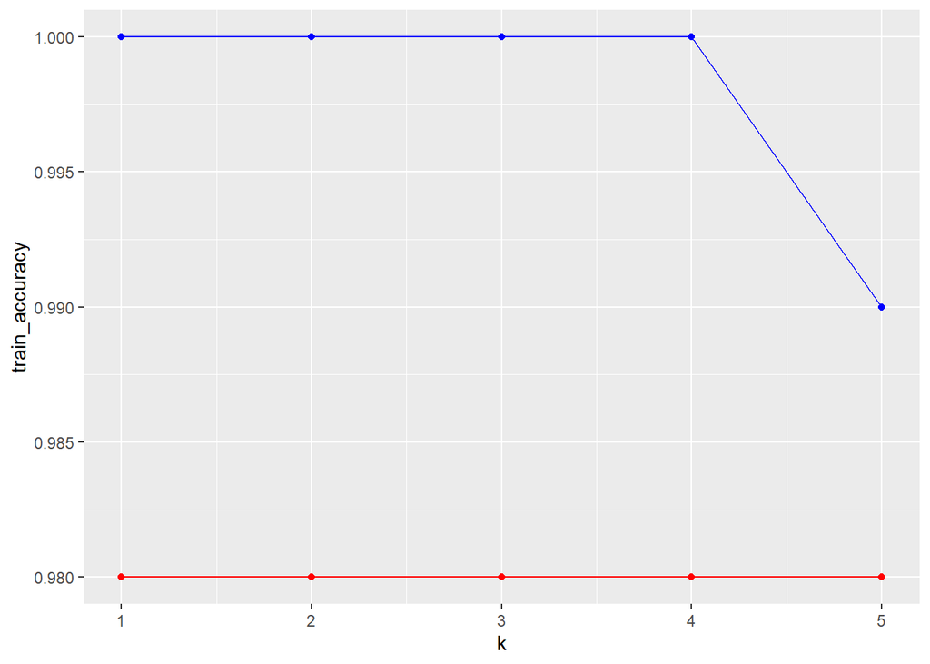

```r
knn_tune%>% select(-mod, -mod_test)%>%
  ggplot()+
  geom_point(aes(k, train_accuracy), color= "blue")+
  geom_line(aes(k, train_accuracy), color= "blue")+
  geom_point(aes(k, test_accuracy), color= "red")+
  geom_line(aes(k, test_accuracy), color= "red")
```

K-value of 1~4 gives the best parameters for all metrics.

The larger k is, the smoother the classification boundary. i.e the complexity of KNN falls as k increases. Therfore, we choose K value of 4.

## Question 1b) Decision Tree

```r
mod_dtree <- decision_tree(mode = "classification") %>%
  set_engine("rpart", control = rpart.control(cp = 0.002, minbucket = 30)) %>%
  fit(Species ~ ., data = train)

pred_dtree <- pred %>%
  bind_cols(
    predict(mod_dtree, new_data = train, type = "class")
  ) %>%
  rename(Species_dtree_train = .pred_class)


pred_test <- test %>%
  select(Species)

pred_test_dtree <- pred_test %>%
  bind_cols(
    predict(mod_dtree, new_data = test, type = "class")
  ) %>%
  rename(Species_dtree_test = .pred_class)

pred_dtree %>%
  conf_mat(Species, Species_dtree_train)
```

```
##             Truth
## Prediction   setosa versicolor virginica
##   setosa         31          0         0
##   versicolor      0         35        34
##   virginica       0          0         0
```

```r
pred_test_dtree %>%
  conf_mat(Species, Species_dtree_test)
```

```
##             Truth
## Prediction   setosa versicolor virginica
##   setosa         19          0         0
##   versicolor      0         15        16
##   virginica       0          0         0
```

#Computed accuracy based on confusion matrix

Accuracy of Decision Tree model on training dataset is:

```r
pred_dtree %>%
  conf_mat(Species, Species_dtree_train)%>% tidy() %>% accuracy_cmat()
```

```
## [1] 0.66
```

Accuracy of Decision Tree model on testing dataset is:

```r
pred_test_dtree %>%
  conf_mat(Species, Species_dtree_test)%>% tidy() %>% accuracy_cmat()
```

```
## [1] 0.68
```

Can also use:

accuracy(pred_dtree, Species, Species_dtree_train)

accuracy(pred_test_dtree, Species, Species_dtree_test)

## Question 1c)

```r
mod_forest <- rand_forest(
  mode = "classification",
  mtry = 2,
  trees = 500
) %>%
  set_engine("randomForest") %>%
  fit(Species~., data = train)


pred_forest <- pred %>%
  bind_cols(
    predict(mod_forest, new_data = train, type = "class")
  ) %>%
  rename(Species_forest_train = .pred_class)


pred_test <- test %>%
  select(Species)

pred_test_forest <- pred_test %>%
  bind_cols(
    predict(mod_forest, new_data = test, type = "class")
  ) %>%
  rename(Species_forest_test = .pred_class)
```

Computed accuracy based on confusion matrix

Accuracy of Random Forest model on training dataset is:

```r
pred_forest %>%
  conf_mat(Species, Species_forest_train)%>% tidy() %>% accuracy_cmat()
```

```
## [1] 1
```

Computed accuracy based on confusion matrix Accuracy of Random Forest model on testing dataset is:

```r
pred_test_forest %>%
  conf_mat(Species, Species_forest_test)%>% tidy() %>% accuracy_cmat()
```

```
## [1] 0.98
```

Can also use:

accuracy(pred_forest, Species, Species_forest_train)

accuracy(pred_test_forest, Species, Species_forest_test)

## Question 1d) Naives Bayes

Training dataset Naives Bayes

```r
dmod_nb <- naiveBayes(Species~., data = train)
table_nb = table(real = train$Species, pred = predict(dmod_nb, train))
table_nb
```

```
##             pred
## real         setosa versicolor virginica
##   setosa         31          0         0
##   versicolor      0         33         2
##   virginica       0          3        31
```

```r
(table_nb[1,1]+ table_nb[2,2]+table_nb[3,3])/sum(table_nb)
```

```
## [1] 0.95
```

Testing dataset Naives Bayes

```r
table_nb_test = table(real = test$Species, pred = predict(dmod_nb, test))
table_nb_test
```

```
##             pred
## real         setosa versicolor virginica
##   setosa         19          0         0
##   versicolor      0         15         0
##   virginica       0          1        15
```

```r
(table_nb_test[1,1]+ table_nb_test[2,2]+table_nb_test[3,3])/sum(table_nb_test)
```

```
## [1] 0.98
```

# Question 2

## Question 2a)

Implement k-Means algorithm with k = 3 and compare that result to the “true” value Species which is not used in the algorithm

```r
set.seed(1111)

data_scale =data %>%  select(-Species) %>%  scale()


km.out_2a <- kmeans(data_scale, 3, nstart = 25)

km.out_2a$betweenss/km.out_2a$totss*100
```

```
## [1] 76.69658
```

76.7% of the total variance in iris data set is explained by the clustering.

```r
table(km.out_2a$cluster, data$Species)
```

```
##
##     setosa versicolor virginica
##   1      0         11        36
##   2     50          0         0
##   3      0         39        14
```

Cluster 2 is setosa Cluster 1 and 3 are mixed with versicolor and virginica meaning that the K-means algorithm is not clustering the versicolor and virginica species well but seperates setosa well.

[figure not shown]

```r
plot(data_scale, col = (km.out_2a$cluster + 1),
     main = "K-Means Clustering Results with K = 2",
     xlab = "", ylab = "", pch = 20, cex = 2)
```

## Question 2b)

```r
km.out_2b <- kmeans(data_scale, 2, nstart = 25)
km.out_2b$betweenss/km.out_2b$totss*100
```

```
## [1] 62.93972
```

62.9% of the total variance in iris data set is explained by the clustering. The more clusters the higher this value will be.

```r
table(km.out_2b$cluster, data$Species)
```

```
##
##     setosa versicolor virginica
##   1      0         50        50
##   2     50          0         0
```

Setosa is easily seperated from the versicolor and virginica as shown in the kmeans model of 3 clusters.

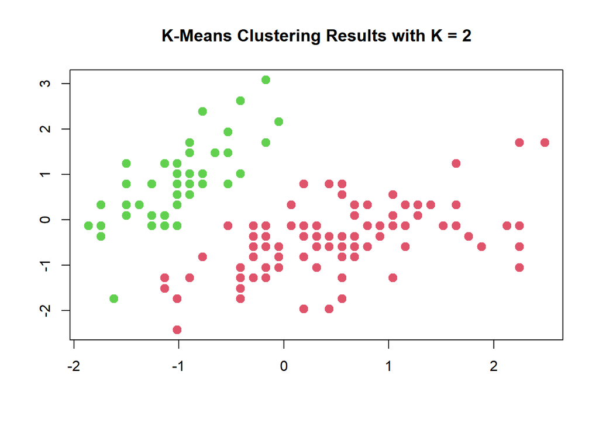

```r
plot(data_scale, col = (km.out_2b$cluster + 1),
     main = "K-Means Clustering Results with K = 2",
     xlab = "", ylab = "", pch = 20, cex = 2)
```

We can see the top left cluster the same as the kmeans (cluster=3) plot in question 2a)

## Question 2c)

```r
km.out_2c <- kmeans(data_scale, 4, nstart = 25)
km.out_2c$betweenss/km.out_2c$totss*100
```

```
## [1] 80.98463
```

```r
table(km.out_2c$cluster, data$Species)
```

```
##
##     setosa versicolor virginica
##   1     25          0         0
##   2     25          0         0
##   3      0         39        14
##   4      0         11        36
```

[figure not shown]

```r
plot(data_scale, col = (km.out_2c$cluster + 1),
     main = "K-Means Clustering Results with K = 2",
     xlab = "", ylab = "", pch = 20, cex = 2)
```

## Question 2d)

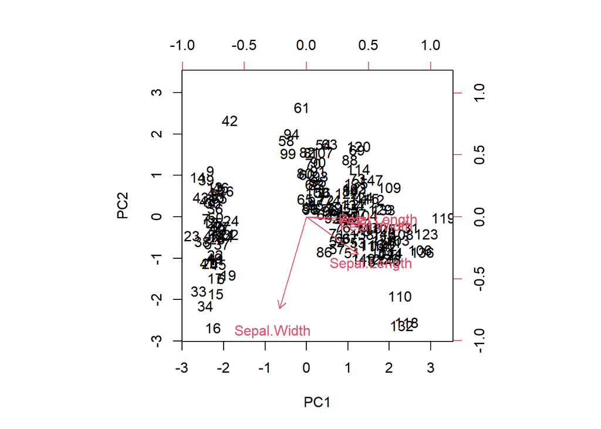

```r
pr.out = prcomp(data[1:4], scale=TRUE)
biplot(pr.out, scale = 0)
```

```r
pve= pr.out$sdev^2/sum(pr.out$sdev^2)
pve
```

```
## [1] 0.729624454 0.228507618 0.036689219 0.005178709
```

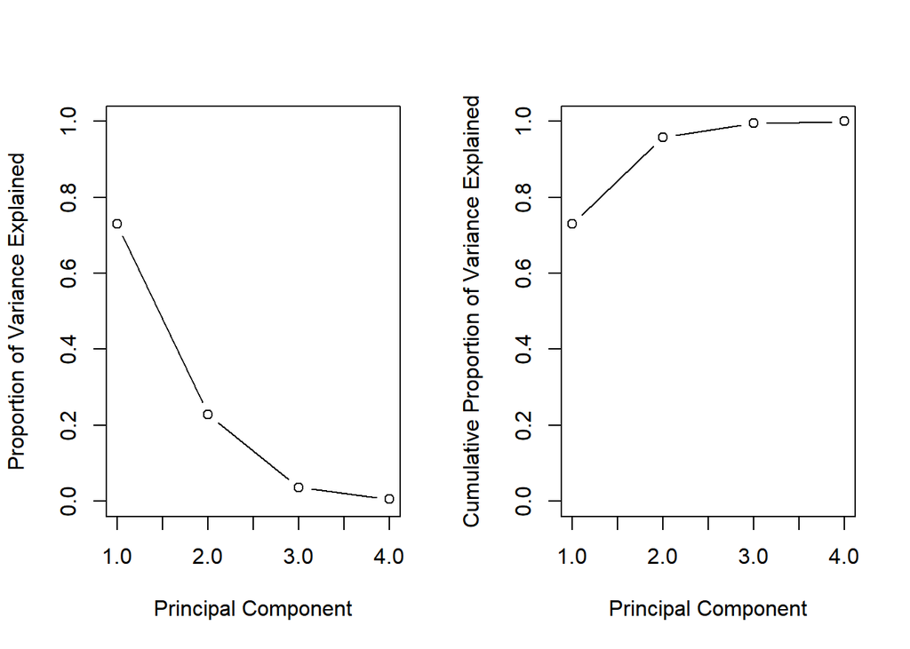

```r
par(mfrow= c(1,2))
plot(pve, xlab = "Principal Component",
     ylab = "Proportion of Variance Explained", ylim = c(0, 1),
     type = "b")


plot(cumsum(pve), xlab = "Principal Component",
     ylab = "Cumulative Proportion of Variance Explained",
     ylim = c(0, 1), type = "b")
```

We use the first 2 PCs which explain 95.8% of the variance in the data

```r
pr.out$rotation[,1:2] %>% as.data.frame()
```

```
##                     PC1         PC2
## Sepal.Length  0.5210659 -0.37741762
## Sepal.Width  -0.2693474 -0.92329566
## Petal.Length  0.5804131 -0.02449161
## Petal.Width   0.5648565 -0.06694199
```

Interpreting the two componenets: Sepal.Length, Sepal.Length and Petal Width havea large positive loading on PC1. This means that PC1 is positively correlated with these variables. This suggests that these three predictor variables vary together. This is seen in the plots of PC1 and PC2.

Sepal Width has a large negative loading on PC2. This means that PC2 is negatively correlated with these variables.

## Question 2e)

```r
#Limit components to the first 2 using rank parameter
pr.out_k = prcomp(data[1:4], scale=TRUE,rank=2)

#Predict Iris species using predict()
pc_predict = predict(pr.out_k, newdata= data[1:4])

#Run k means
pc_k_out=kmeans(pc_predict, 3, nstart = 25)
pc_k_out$betweenss/pc_k_out$totss*100
```

```
## [1] 79.99219
```

```r
table(pc_k_out$cluster, data$Species)
```

```
##
##     setosa versicolor virginica
##   1      0         11        36
##   2     50          0         0
##   3      0         39        14
```

[figure not shown]

```r
plot(data_scale, col = (pc_k_out$cluster + 1),
     main = "K-Means Clustering Results with K = 2",
     xlab = "", ylab = "", pch = 20, cex = 2)
```